# Compare model structures with brms

C. Susannah Tysor

01 September, 2021

```r
knitr::opts_chunk$set(message = FALSE, echo = FALSE)
```

While I have data for both the start and end of flowering for males and females, I am only doing a model structure comparison on the female end data. Leave-one-out optimization of interval censored data in `brms` is easier for end-of-flowering than start-of-flowering because of the way it codes upper and lower bounds.

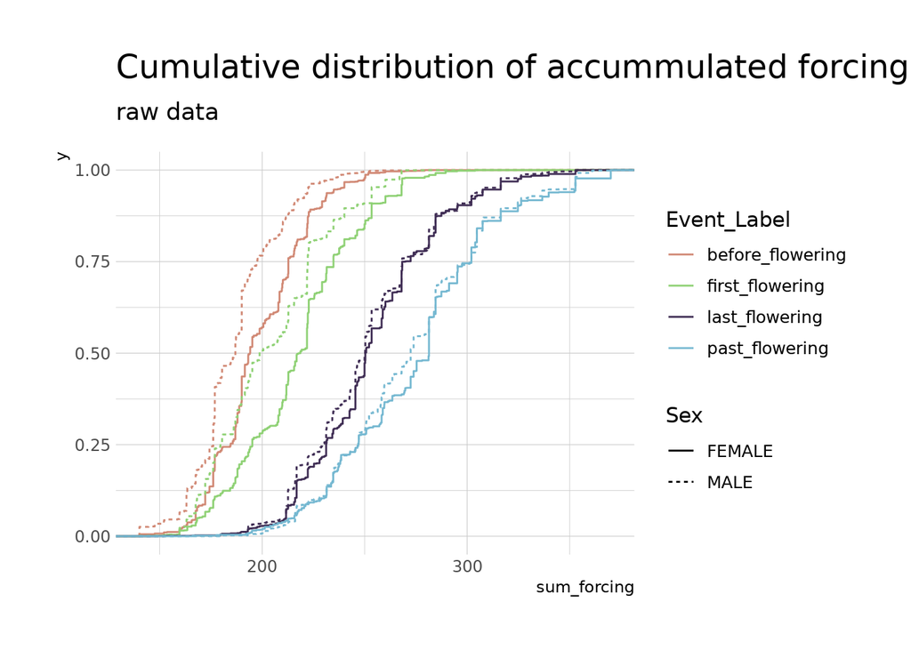

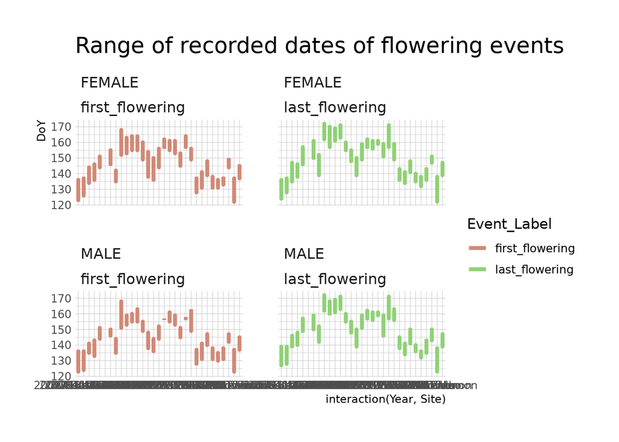

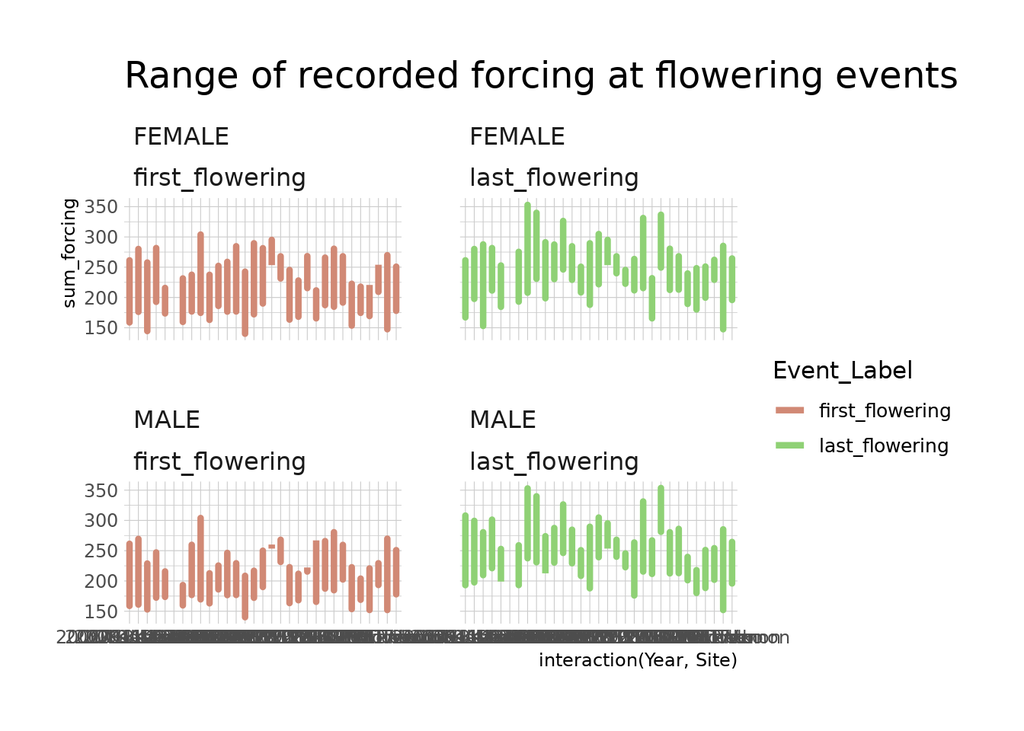

Female end-of-flowering data

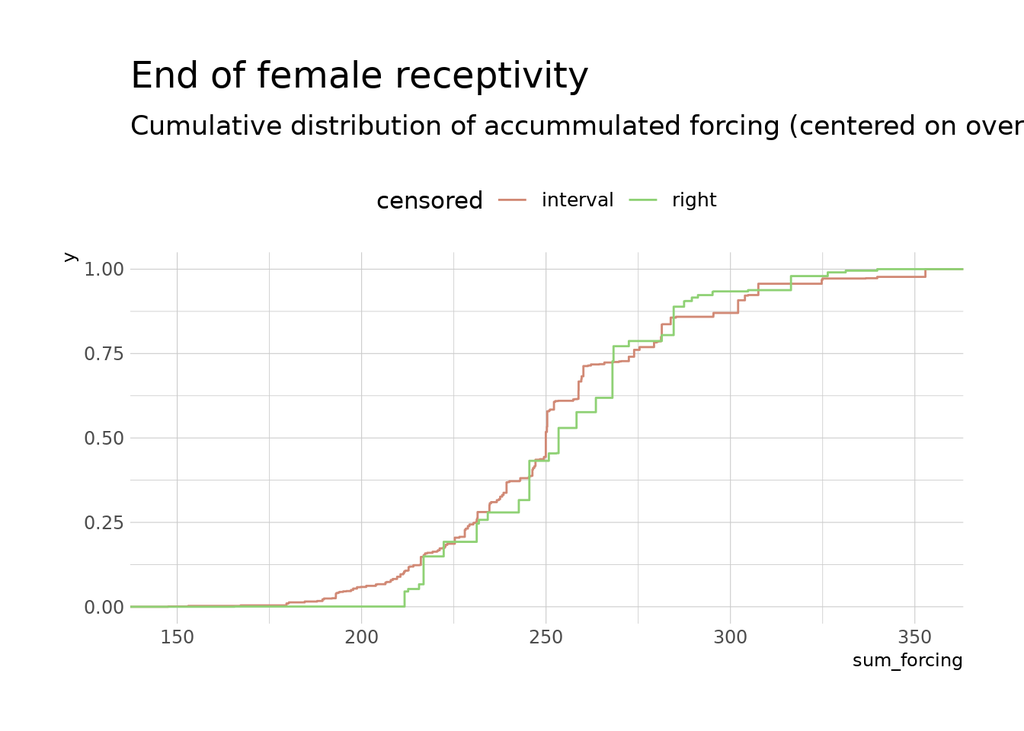

## Censoring

All of the data is either end censored or interval censored. End censoring occurs when the tree was receptive on the last day of observation. Interval censoring occurs because we do not observe the exact moment receptivity ends. It is particularly important to account for this as the time (and resulting amount of forcing) between when the tree was observed not yet receptive and receptive may be large.

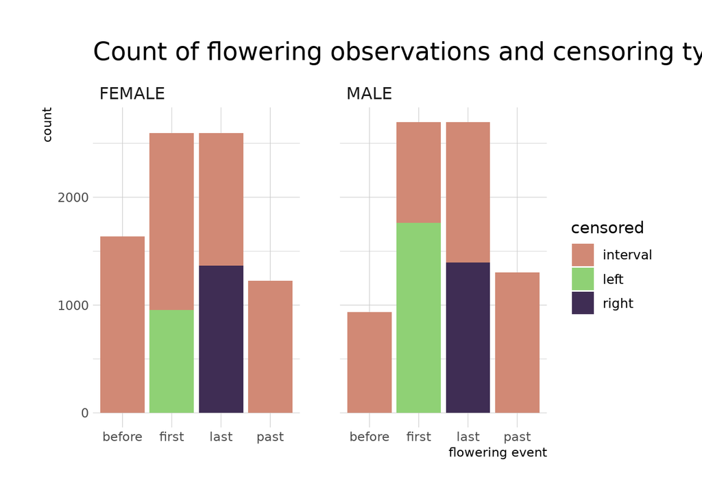

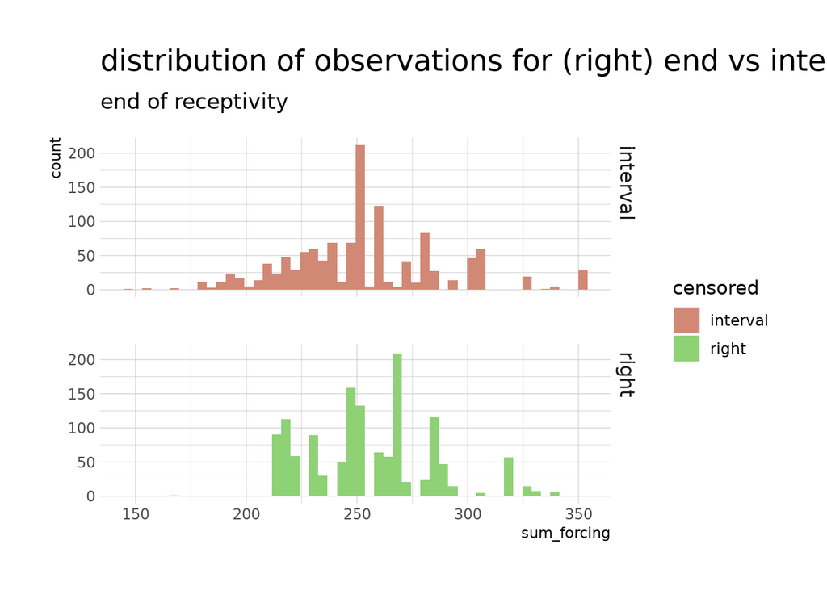

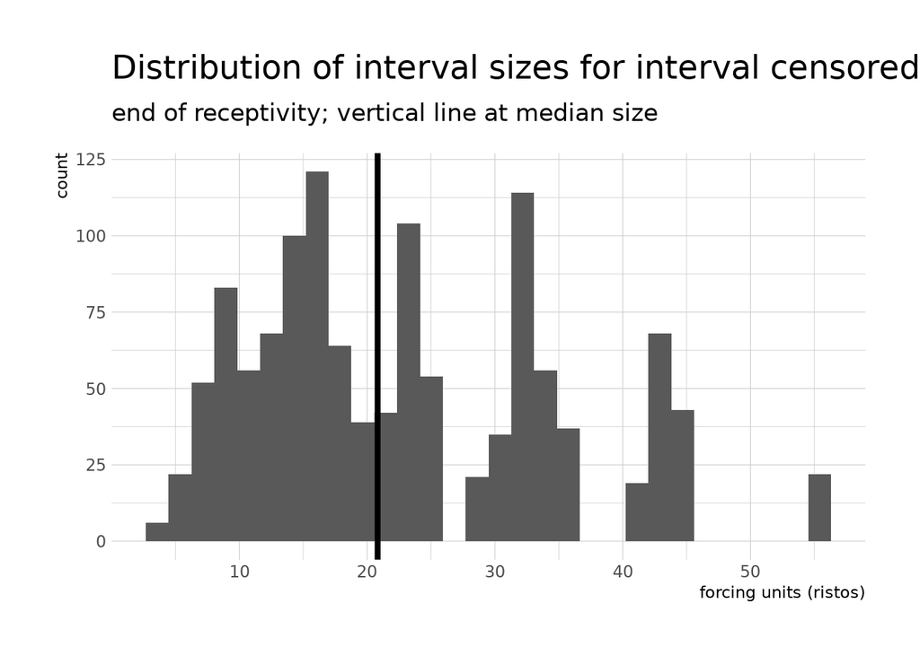

## Fit Models and calculate leave-one-out cross validation elpds

Models were fit with `brms::brm` and compared with `brms::loo`.

## Model results

### Model 1: Mean only model

In the simplest possible model, we fit only the population mean and standard deviation with weakly informative priors.

$\mathrm{y} \sim \mathrm{Normal}(\mu,\sigma)$

$\mu \sim \mathrm{Normal}(400,100)$

$\sigma \sim |\mathrm{Normal}(0,15)|$

```
## // generated with brms 2.16.1
## functions {
## }
## data {
##   int<lower=1> N;  // total number of observations
##   vector[N] Y;  // response variable
##   int prior_only;  // should the likelihood be ignored?
## }
## transformed data {
## }
## parameters {
##   real Intercept;  // temporary intercept for centered predictors
##   real<lower=0> sigma;  // dispersion parameter
## }
## transformed parameters {
## }
## model {
##   // likelihood including constants
##   if (!prior_only) {
##     // initialize linear predictor term
##     vector[N] mu = Intercept + rep_vector(0.0, N);
##     target += normal_lpdf(Y | mu, sigma);
##   }
##   // priors including constants
##   target += normal_lpdf(Intercept | 400,100);
##   target += normal_lpdf(sigma | 0,15)
##     - 1 * normal_lccdf(0 | 0,15);
## }
## generated quantities {
##   // actual population-level intercept
##   real b_Intercept = Intercept;
## }
```

```
##            prior     class coef group resp dpar nlpar bound source
##  normal(400,100) Intercept                                    user
##     normal(0,15)     sigma                                    user
```

```
##  Family: gaussian
##   Links: mu = identity; sigma = identity
## Formula: sum_forcing ~ 1
##    Data: fedat (Number of observations: 2593)
##   Draws: 4 chains, each with iter = 2000; warmup = 1000; thin = 1;
##          total post-warmup draws = 4000
##
## Population-Level Effects:
##           Estimate Est.Error l-95% CI u-95% CI Rhat Bulk_ESS Tail_ESS
## Intercept   254.14      0.64   252.91   255.43 1.00     3175     2741
##
## Family Specific Parameters:
##       Estimate Est.Error l-95% CI u-95% CI Rhat Bulk_ESS Tail_ESS
## sigma    31.77      0.45    30.90    32.64 1.00     3682     2537
##
## Draws were sampled using sampling(NUTS). For each parameter, Bulk_ESS
## and Tail_ESS are effective sample size measures, and Rhat is the potential
## scale reduction factor on split chains (at convergence, Rhat = 1).
```

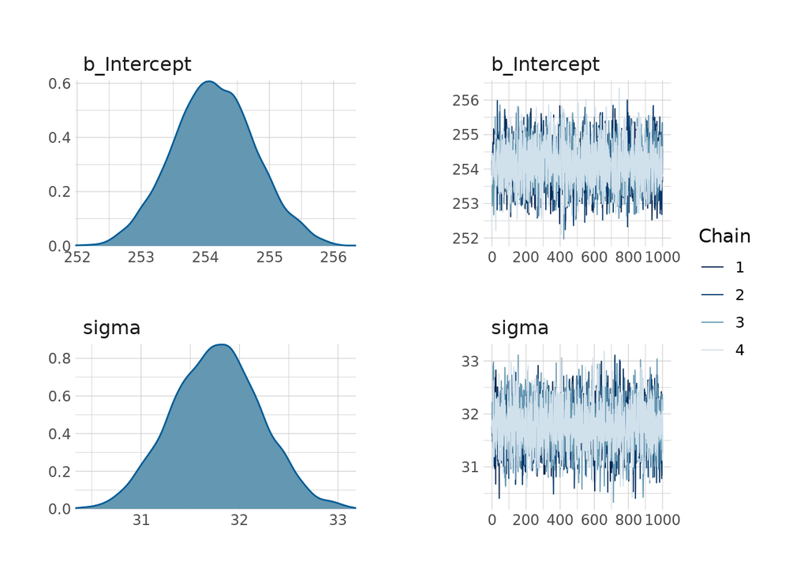

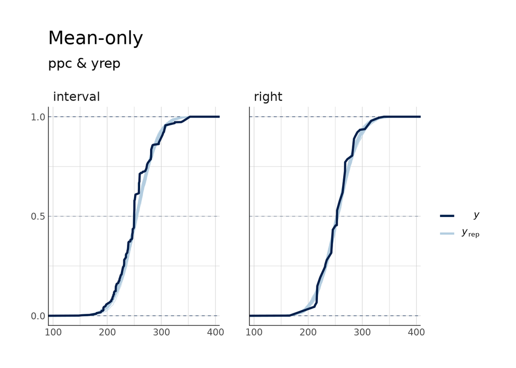

Retrodicting observations from the posterior shows approximate agreement with the data (`y`), but if we consider the Kaplan-Meier estimate for the right censored data compared to the empirical ccdf estimates of each dataset, we see that the model performs very poorly. This is not unexpected since we haven’t actually accounted for censorship at all in this model.

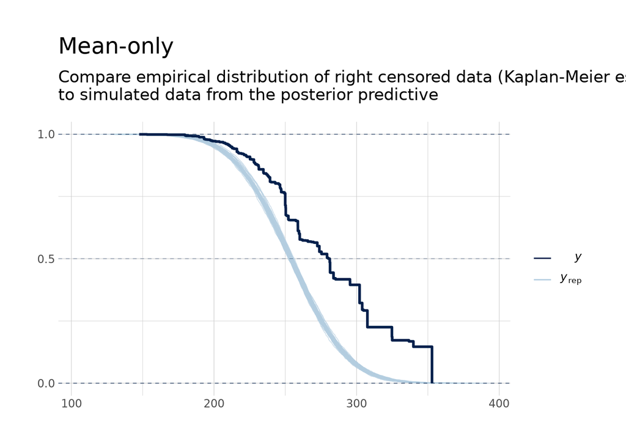

### Model 2: Mean-only with end censoring

Here we account for end censoring but not interval censoring. If the last time a tree is observed, it is still flowering, that day is a lower bound on the true last day of flowering and it is end censored.

The overall model is the same

$\mathrm{y} \sim \mathrm{Normal}(\mu,\sigma)$

$\mu \sim \mathrm{Normal}(400,100)$

$\sigma \sim |\mathrm{Normal}(0,15)|$

but for right-censored data, the likelihood for the observations is

$\mathrm{Pr}(y > U) = \int_\infty^U \mathrm{Normal}(y|\mu, \sigma)$, where $U$ is the forcing on the last day we observed the tree. This works out to be the complement of the cumulative normal distribution function.

$\mathrm{y} \sim \mathrm{Normal ccdf}(\mu, \sigma)$

```
## // generated with brms 2.16.1
## functions {
## }
## data {
##   int<lower=1> N;  // total number of observations
##   vector[N] Y;  // response variable
##   int<lower=-1,upper=2> cens[N];  // indicates censoring
##   int prior_only;  // should the likelihood be ignored?
## }
## transformed data {
## }
## parameters {
##   real Intercept;  // temporary intercept for centered predictors
##   real<lower=0> sigma;  // dispersion parameter
## }
## transformed parameters {
## }
## model {
##   // likelihood including constants
##   if (!prior_only) {
##     // initialize linear predictor term
##     vector[N] mu = Intercept + rep_vector(0.0, N);
##     for (n in 1:N) {
##     // special treatment of censored data
##       if (cens[n] == 0) {
##         target += normal_lpdf(Y[n] | mu[n], sigma);
##       } else if (cens[n] == 1) {
##         target += normal_lccdf(Y[n] | mu[n], sigma);
##       } else if (cens[n] == -1) {
##         target += normal_lcdf(Y[n] | mu[n], sigma);
##       }
##     }
##   }
##   // priors including constants
##   target += normal_lpdf(Intercept | 400,100);
##   target += normal_lpdf(sigma | 0,15)
##     - 1 * normal_lccdf(0 | 0,15);
## }
## generated quantities {
##   // actual population-level intercept
##   real b_Intercept = Intercept;
## }
```

```
##            prior     class coef group resp dpar nlpar bound source
##  normal(400,100) Intercept                                    user
##     normal(0,15)     sigma                                    user
```

```
##  Family: gaussian
##   Links: mu = identity; sigma = identity
## Formula: sum_forcing | cens(censored_lronly) ~ 1
##    Data: fedat (Number of observations: 2593)
##   Draws: 4 chains, each with iter = 2000; warmup = 1000; thin = 1;
##          total post-warmup draws = 4000
##
## Population-Level Effects:
##           Estimate Est.Error l-95% CI u-95% CI Rhat Bulk_ESS Tail_ESS
## Intercept   278.26      1.07   276.20   280.38 1.00     2049     2226
##
## Family Specific Parameters:
##       Estimate Est.Error l-95% CI u-95% CI Rhat Bulk_ESS Tail_ESS
## sigma    41.98      0.87    40.30    43.73 1.00     2197     2549
##
## Draws were sampled using sampling(NUTS). For each parameter, Bulk_ESS
## and Tail_ESS are effective sample size measures, and Rhat is the potential
## scale reduction factor on split chains (at convergence, Rhat = 1).
```

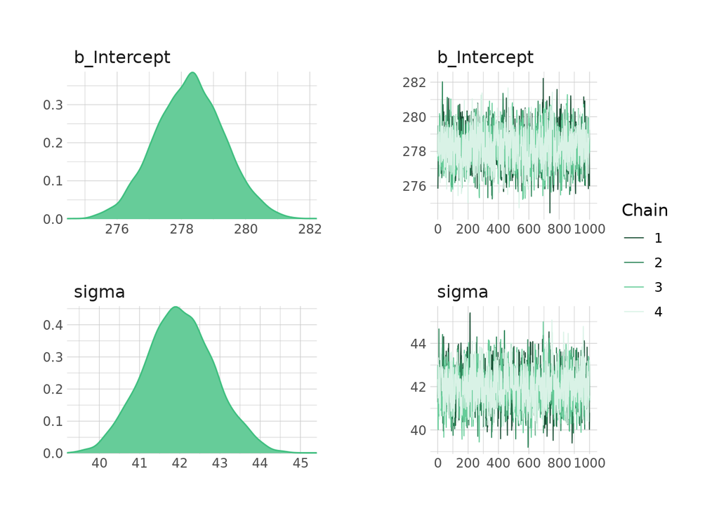

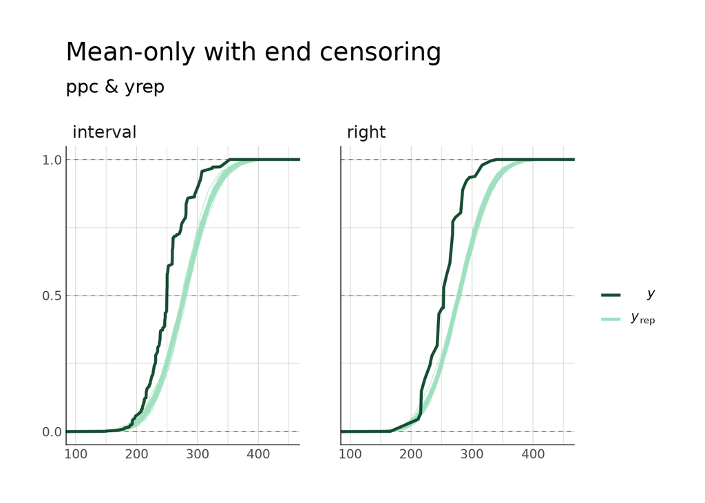

This time we see that the predictions for both interval and right censored data occur well after the data we observed. The Kaplan-Meier estimate suggests this model is a better fit at least for our right censored data.

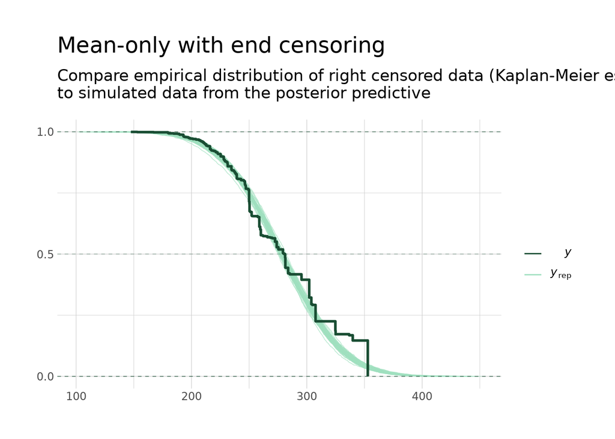

### Model 3: Mean-only with end AND interval censoring

In the third model, we still only fit the mean and standard deviation, but we account for both end and interval censoring.

The overall model remains the same

$\mathrm{y} \sim \mathrm{Normal}(\mu,\sigma)$

$\mu \sim \mathrm{Normal}(400,100)$

$\sigma \sim |\mathrm{Normal}(0,15)|$

and right censored data is handled as before,

$\mathrm{U} \sim \mathrm{Normal ccdf}(\mu, \sigma)$

while the likelihood for interval censored data is

$\mathrm{Pr}(L < y < U) = \int_L^U \mathrm{Normal}(y|\mu, \sigma)\mathrm{d}y$ which is

$\mathrm{Normalcdf}(U | \mu, \sigma) - \mathrm{Normalcdf}(L|\mu, \sigma)$

```
## // generated with brms 2.16.1
## functions {
## }
## data {
##   int<lower=1> N;  // total number of observations
##   vector[N] Y;  // response variable
##   int<lower=-1,upper=2> cens[N];  // indicates censoring
##   vector[N] rcens;  // right censor points for interval censoring
##   int prior_only;  // should the likelihood be ignored?
## }
## transformed data {
## }
## parameters {
##   real Intercept;  // temporary intercept for centered predictors
##   real<lower=0> sigma;  // dispersion parameter
## }
## transformed parameters {
## }
## model {
##   // likelihood including constants
##   if (!prior_only) {
##     // initialize linear predictor term
##     vector[N] mu = Intercept + rep_vector(0.0, N);
##     for (n in 1:N) {
##     // special treatment of censored data
##       if (cens[n] == 0) {
##         target += normal_lpdf(Y[n] | mu[n], sigma);
##       } else if (cens[n] == 1) {
##         target += normal_lccdf(Y[n] | mu[n], sigma);
##       } else if (cens[n] == -1) {
##         target += normal_lcdf(Y[n] | mu[n], sigma);
##       } else if (cens[n] == 2) {
##         target += log_diff_exp(
##           normal_lcdf(rcens[n] | mu[n], sigma),
##           normal_lcdf(Y[n] | mu[n], sigma)
##         );
##       }
##     }
##   }
##   // priors including constants
##   target += normal_lpdf(Intercept | 400,100);
##   target += normal_lpdf(sigma | 0,15)
##     - 1 * normal_lccdf(0 | 0,15);
## }
## generated quantities {
##   // actual population-level intercept
##   real b_Intercept = Intercept;
## }
```

```
##            prior     class coef group resp dpar nlpar bound source
##  normal(400,100) Intercept                                    user
##     normal(0,15)     sigma                                    user
```

```
##  Family: gaussian
##   Links: mu = identity; sigma = identity
## Formula: sum_forcing | cens(censored, upper) ~ 1
##    Data: fedat (Number of observations: 2593)
##   Draws: 4 chains, each with iter = 2000; warmup = 1000; thin = 1;
##          total post-warmup draws = 4000
##
## Population-Level Effects:
##           Estimate Est.Error l-95% CI u-95% CI Rhat Bulk_ESS Tail_ESS
## Intercept   284.84      1.01   282.85   286.82 1.00     2337     2366
##
## Family Specific Parameters:
##       Estimate Est.Error l-95% CI u-95% CI Rhat Bulk_ESS Tail_ESS
## sigma    39.55      0.80    37.99    41.17 1.00     2274     2314
##
## Draws were sampled using sampling(NUTS). For each parameter, Bulk_ESS
## and Tail_ESS are effective sample size measures, and Rhat is the potential
## scale reduction factor on split chains (at convergence, Rhat = 1).
```

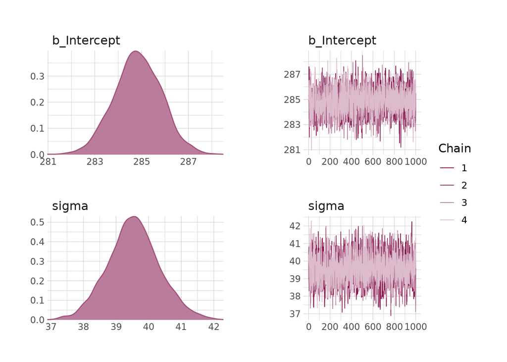

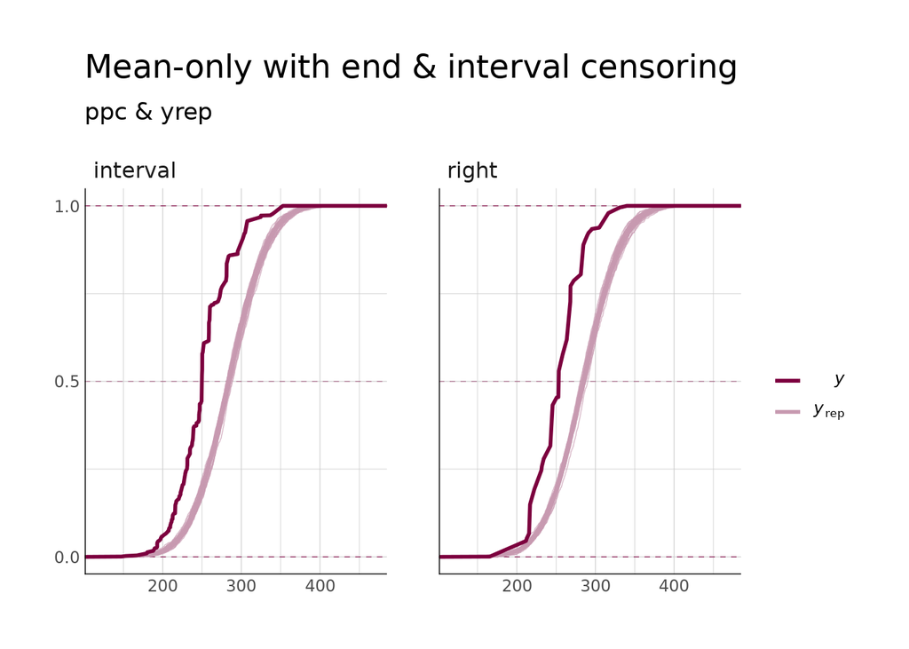

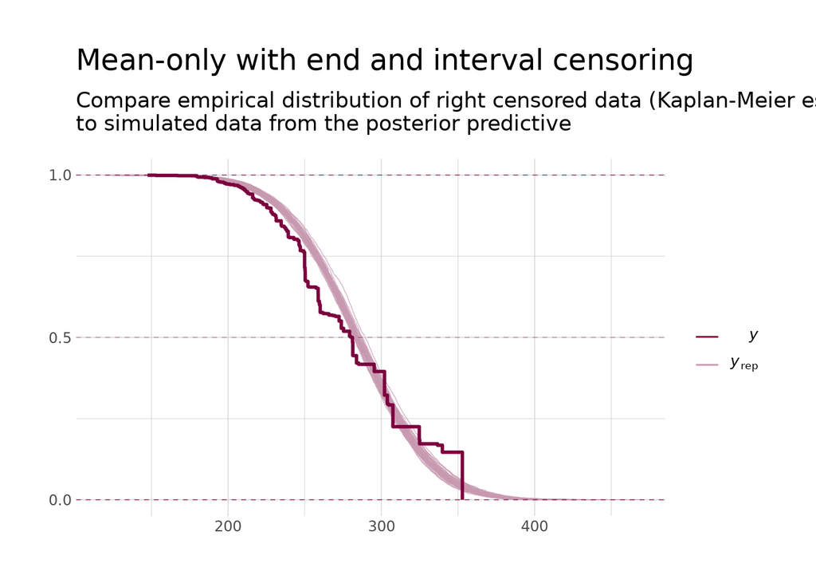

# Is censoring important to include?

Including both interval and end censoring dramatically improves the model by loo metrics.

```
##      elpd_diff se_diff
## mocf     0.0       0.0
## moc  -3800.3      77.8
## mo   -9447.9      54.6
```

# Model 4: Model with full effects and censorship

```
## // generated with brms 2.16.1
## functions {
## }
## data {
##   int<lower=1> N;  // total number of observations
##   vector[N] Y;  // response variable
##   int<lower=-1,upper=2> cens[N];  // indicates censoring
##   vector[N] rcens;  // right censor points for interval censoring
##   // data for group-level effects of ID 1
##   int<lower=1> N_1;  // number of grouping levels
##   int<lower=1> M_1;  // number of coefficients per level
##   int<lower=1> J_1[N];  // grouping indicator per observation
##   // group-level predictor values
##   vector[N] Z_1_1;
##   // data for group-level effects of ID 2
##   int<lower=1> N_2;  // number of grouping levels
##   int<lower=1> M_2;  // number of coefficients per level
##   int<lower=1> J_2[N];  // grouping indicator per observation
##   // group-level predictor values
##   vector[N] Z_2_1;
##   // data for group-level effects of ID 3
##   int<lower=1> N_3;  // number of grouping levels
##   int<lower=1> M_3;  // number of coefficients per level
##   int<lower=1> J_3[N];  // grouping indicator per observation
##   // group-level predictor values
##   vector[N] Z_3_1;
##   // data for group-level effects of ID 4
##   int<lower=1> N_4;  // number of grouping levels
##   int<lower=1> M_4;  // number of coefficients per level
##   int<lower=1> J_4[N];  // grouping indicator per observation
##   // group-level predictor values
##   vector[N] Z_4_1;
##   int prior_only;  // should the likelihood be ignored?
## }
## transformed data {
## }
## parameters {
##   real Intercept;  // temporary intercept for centered predictors
##   real<lower=0> sigma;  // dispersion parameter
##   vector<lower=0>[M_1] sd_1;  // group-level standard deviations
```

[output cut: 49 more lines]

```
##   target += std_normal_lpdf(z_1[1]);
##   target += normal_lpdf(sd_2 | 0,9)
##     - 1 * normal_lccdf(0 | 0,9);
##   target += std_normal_lpdf(z_2[1]);
##   target += normal_lpdf(sd_3 | 0,9)
##     - 1 * normal_lccdf(0 | 0,9);
##   target += std_normal_lpdf(z_3[1]);
##   target += normal_lpdf(sd_4 | 0,9)
##     - 1 * normal_lccdf(0 | 0,9);
##   target += std_normal_lpdf(z_4[1]);
## }
## generated quantities {
##   // actual population-level intercept
##   real b_Intercept = Intercept;
## }
```

```
##            prior     class      coef      group resp dpar nlpar bound
##  normal(400,100) Intercept
##      normal(0,9)        sd
##      normal(0,9)        sd                Clone
##      normal(0,9)        sd Intercept      Clone
##      normal(0,9)        sd           Provenance
##      normal(0,9)        sd Intercept Provenance
##      normal(0,9)        sd                 Site
##      normal(0,9)        sd Intercept       Site
##      normal(0,9)        sd                 Year
##      normal(0,9)        sd Intercept       Year
##     normal(0,15)     sigma
##        source
##          user
##          user
##  (vectorized)
##  (vectorized)
##  (vectorized)
##  (vectorized)
##  (vectorized)
##  (vectorized)
##  (vectorized)
##  (vectorized)
##          user
```

```
##  Family: gaussian
##   Links: mu = identity; sigma = identity
## Formula: sum_forcing | cens(censored, upper) ~ 1 + (1 | Site) + (1 | Provenance) + (1 | Clone) + (1 | Year)
##    Data: fedat (Number of observations: 2593)
##   Draws: 4 chains, each with iter = 2000; warmup = 1000; thin = 1;
##          total post-warmup draws = 4000
##
## Group-Level Effects:
## ~Clone (Number of levels: 258)
##               Estimate Est.Error l-95% CI u-95% CI Rhat Bulk_ESS Tail_ESS
## sd(Intercept)    15.90      1.09    13.81    18.08 1.00     1014     1823
##
## ~Provenance (Number of levels: 7)
##               Estimate Est.Error l-95% CI u-95% CI Rhat Bulk_ESS Tail_ESS
## sd(Intercept)    13.21      3.89     7.11    22.33 1.00     1672     2299
##
## ~Site (Number of levels: 7)
##               Estimate Est.Error l-95% CI u-95% CI Rhat Bulk_ESS Tail_ESS
## sd(Intercept)    22.27      4.05    15.35    31.11 1.00     2530     2631
##
## ~Year (Number of levels: 16)
##               Estimate Est.Error l-95% CI u-95% CI Rhat Bulk_ESS Tail_ESS
## sd(Intercept)    17.78      2.81    13.13    23.90 1.00     1072     2162
##
## Population-Level Effects:
##           Estimate Est.Error l-95% CI u-95% CI Rhat Bulk_ESS Tail_ESS
## Intercept   249.42     11.39   227.35   272.25 1.00     1007     1883
##
## Family Specific Parameters:
##       Estimate Est.Error l-95% CI u-95% CI Rhat Bulk_ESS Tail_ESS
## sigma    17.78      0.45    16.91    18.66 1.00     3741     3164
##
## Draws were sampled using sampling(NUTS). For each parameter, Bulk_ESS
## and Tail_ESS are effective sample size measures, and Rhat is the potential
## scale reduction factor on split chains (at convergence, Rhat = 1).
```

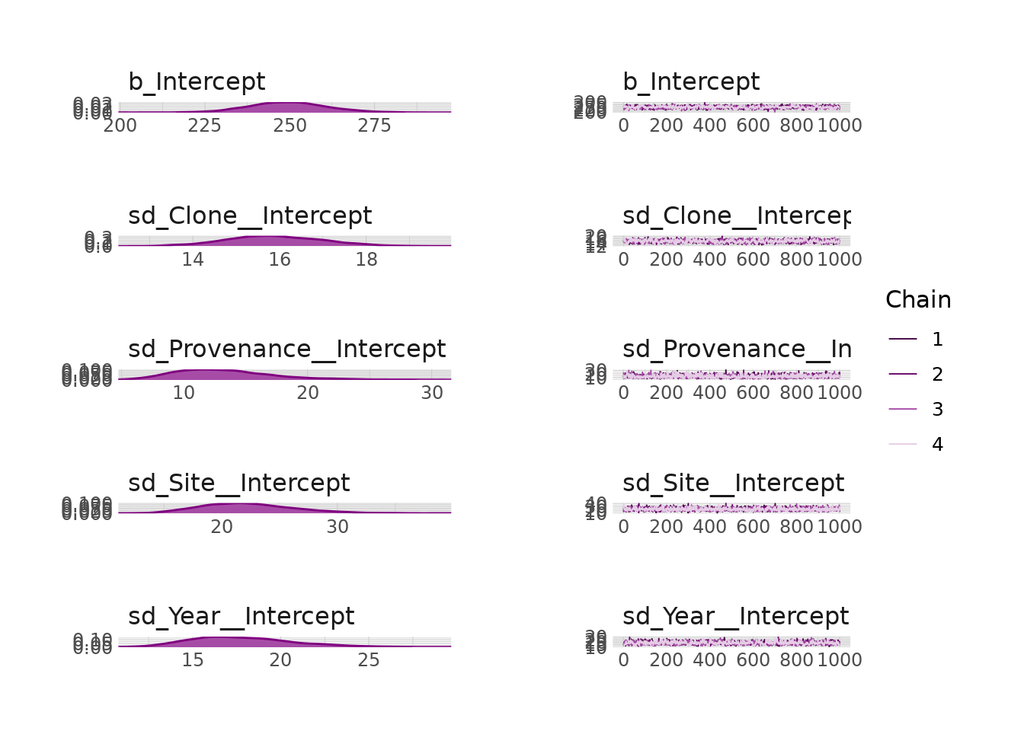

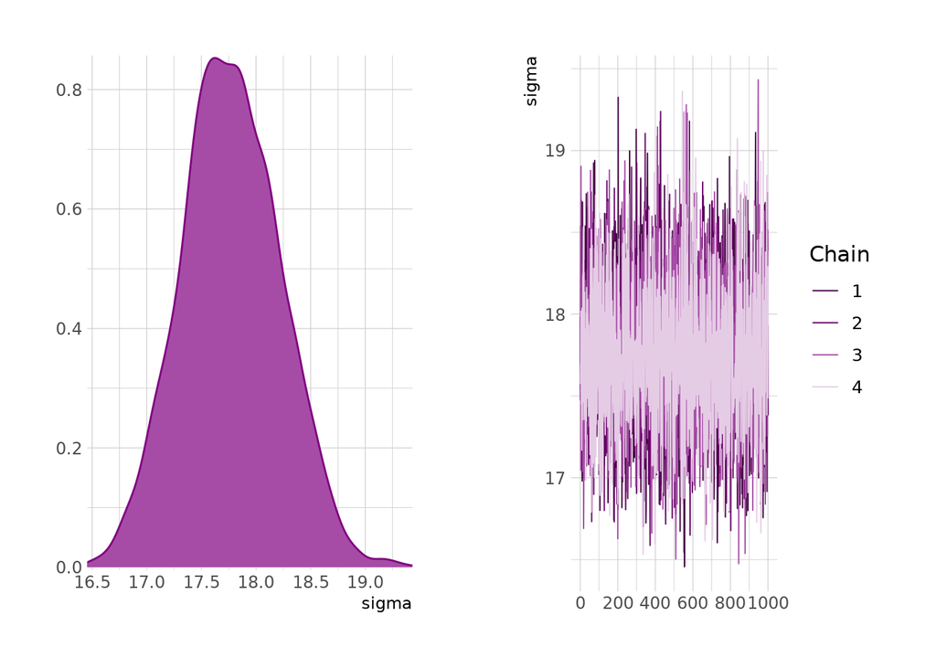

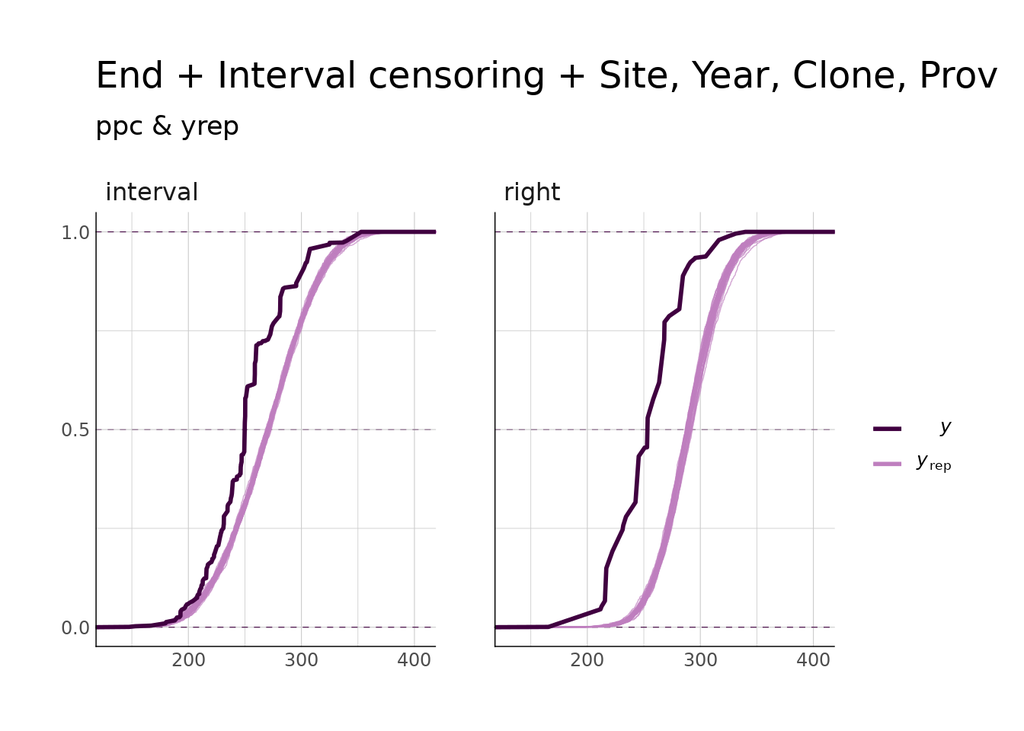

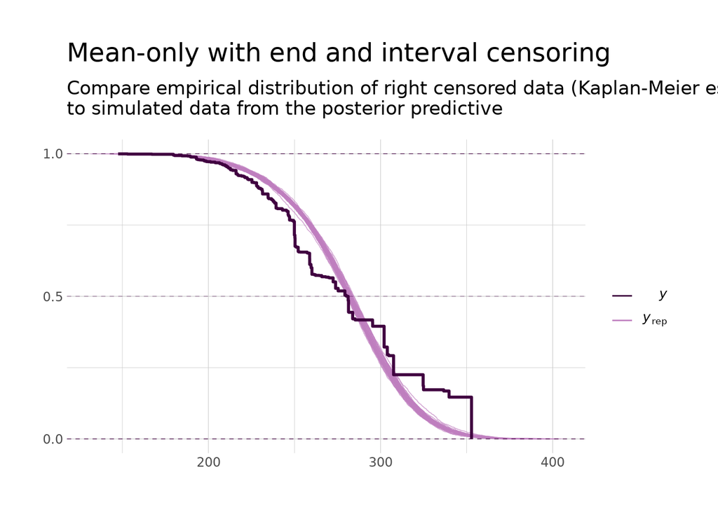

```
## // generated with brms 2.16.1
## functions {
## }
## data {
##   int<lower=1> N;  // total number of observations
##   vector[N] Y;  // response variable
##   int<lower=-1,upper=2> cens[N];  // indicates censoring
##   vector[N] rcens;  // right censor points for interval censoring
##   // data for group-level effects of ID 1
##   int<lower=1> N_1;  // number of grouping levels
##   int<lower=1> M_1;  // number of coefficients per level
##   int<lower=1> J_1[N];  // grouping indicator per observation
##   // group-level predictor values
##   vector[N] Z_1_1;
##   // data for group-level effects of ID 2
##   int<lower=1> N_2;  // number of grouping levels
##   int<lower=1> M_2;  // number of coefficients per level
##   int<lower=1> J_2[N];  // grouping indicator per observation
##   // group-level predictor values
##   vector[N] Z_2_1;
##   // data for group-level effects of ID 3
##   int<lower=1> N_3;  // number of grouping levels
##   int<lower=1> M_3;  // number of coefficients per level
##   int<lower=1> J_3[N];  // grouping indicator per observation
##   // group-level predictor values
##   vector[N] Z_3_1;
##   // data for group-level effects of ID 4
##   int<lower=1> N_4;  // number of grouping levels
##   int<lower=1> M_4;  // number of coefficients per level
##   int<lower=1> J_4[N];  // grouping indicator per observation
##   // group-level predictor values
##   vector[N] Z_4_1;
##   // data for group-level effects of ID 5
##   int<lower=1> N_5;  // number of grouping levels
##   int<lower=1> M_5;  // number of coefficients per level
##   int<lower=1> J_5[N];  // grouping indicator per observation
##   // group-level predictor values
##   vector[N] Z_5_1;
##   int prior_only;  // should the likelihood be ignored?
## }
```

[output cut: 62 more lines]

```
##   target += std_normal_lpdf(z_2[1]);
##   target += normal_lpdf(sd_3 | 0,9)
##     - 1 * normal_lccdf(0 | 0,9);
##   target += std_normal_lpdf(z_3[1]);
##   target += normal_lpdf(sd_4 | 0,9)
##     - 1 * normal_lccdf(0 | 0,9);
##   target += std_normal_lpdf(z_4[1]);
##   target += normal_lpdf(sd_5 | 0,9)
##     - 1 * normal_lccdf(0 | 0,9);
##   target += std_normal_lpdf(z_5[1]);
## }
## generated quantities {
##   // actual population-level intercept
##   real b_Intercept = Intercept;
## }
```

```
##            prior     class      coef      group resp dpar nlpar bound
##  normal(400,100) Intercept
##      normal(0,9)        sd
##      normal(0,9)        sd                Clone
##      normal(0,9)        sd Intercept      Clone
##      normal(0,9)        sd           Provenance
##      normal(0,9)        sd Intercept Provenance
##      normal(0,9)        sd                 Site
##      normal(0,9)        sd Intercept       Site
##      normal(0,9)        sd               TreeID
##      normal(0,9)        sd Intercept     TreeID
##      normal(0,9)        sd                 Year
##      normal(0,9)        sd Intercept       Year
##     normal(0,15)     sigma
##        source
##          user
##          user
##  (vectorized)
##  (vectorized)
##  (vectorized)
##  (vectorized)
##  (vectorized)
##  (vectorized)
##  (vectorized)
##  (vectorized)
##  (vectorized)
##  (vectorized)
##          user
```

```
##  Family: gaussian
##   Links: mu = identity; sigma = identity
## Formula: sum_forcing | cens(censored, upper) ~ 1 + (1 | Site) + (1 | Provenance) + (1 | Clone) + (1 | Year) + (1 | TreeID)
##    Data: fedat (Number of observations: 2593)
##   Draws: 4 chains, each with iter = 3000; warmup = 1500; thin = 1;
##          total post-warmup draws = 6000
##
## Group-Level Effects:
## ~Clone (Number of levels: 258)
##               Estimate Est.Error l-95% CI u-95% CI Rhat Bulk_ESS Tail_ESS
## sd(Intercept)    15.75      1.09    13.75    17.99 1.00     1465     2212
##
## ~Provenance (Number of levels: 7)
##               Estimate Est.Error l-95% CI u-95% CI Rhat Bulk_ESS Tail_ESS
## sd(Intercept)    13.27      3.92     7.12    22.31 1.00     2549     3638
##
## ~Site (Number of levels: 7)
##               Estimate Est.Error l-95% CI u-95% CI Rhat Bulk_ESS Tail_ESS
## sd(Intercept)    22.23      3.98    15.43    30.85 1.00     2627     3601
##
## ~TreeID (Number of levels: 739)
##               Estimate Est.Error l-95% CI u-95% CI Rhat Bulk_ESS Tail_ESS
## sd(Intercept)     2.29      1.42     0.12     5.24 1.01      460     1134
##
## ~Year (Number of levels: 16)
##               Estimate Est.Error l-95% CI u-95% CI Rhat Bulk_ESS Tail_ESS
## sd(Intercept)    17.76      2.92    12.92    24.39 1.00     1156     2066
##
## Population-Level Effects:
##           Estimate Est.Error l-95% CI u-95% CI Rhat Bulk_ESS Tail_ESS
## Intercept   249.67     11.47   227.35   272.75 1.01     1052     1620
##
## Family Specific Parameters:
##       Estimate Est.Error l-95% CI u-95% CI Rhat Bulk_ESS Tail_ESS
## sigma    17.66      0.47    16.75    18.58 1.00     3154     3951
##
## Draws were sampled using sampling(NUTS). For each parameter, Bulk_ESS
## and Tail_ESS are effective sample size measures, and Rhat is the potential
## scale reduction factor on split chains (at convergence, Rhat = 1).
```

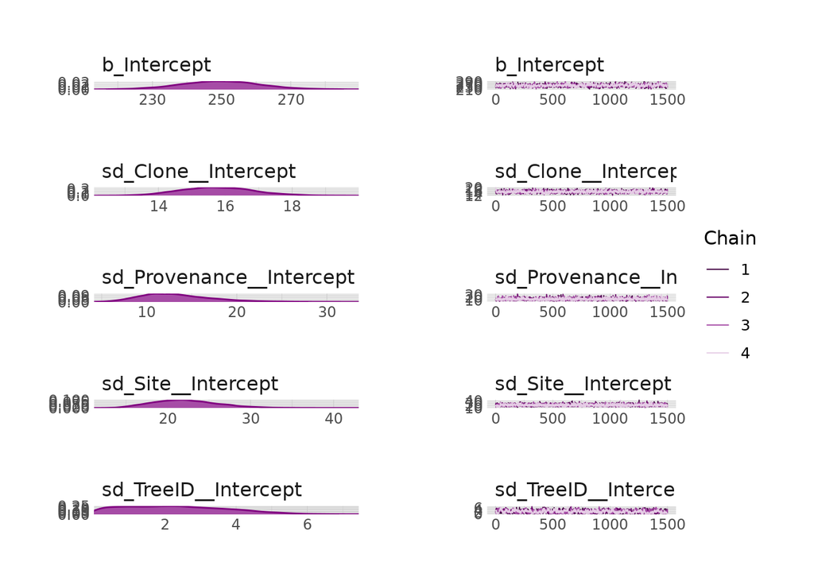

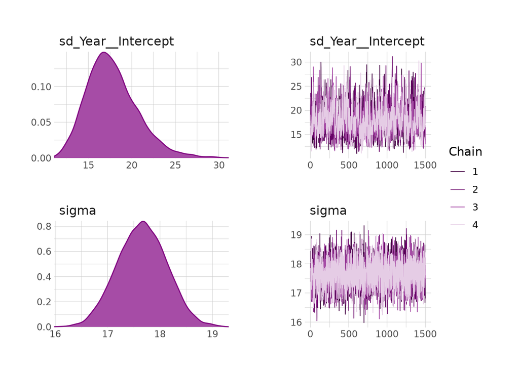

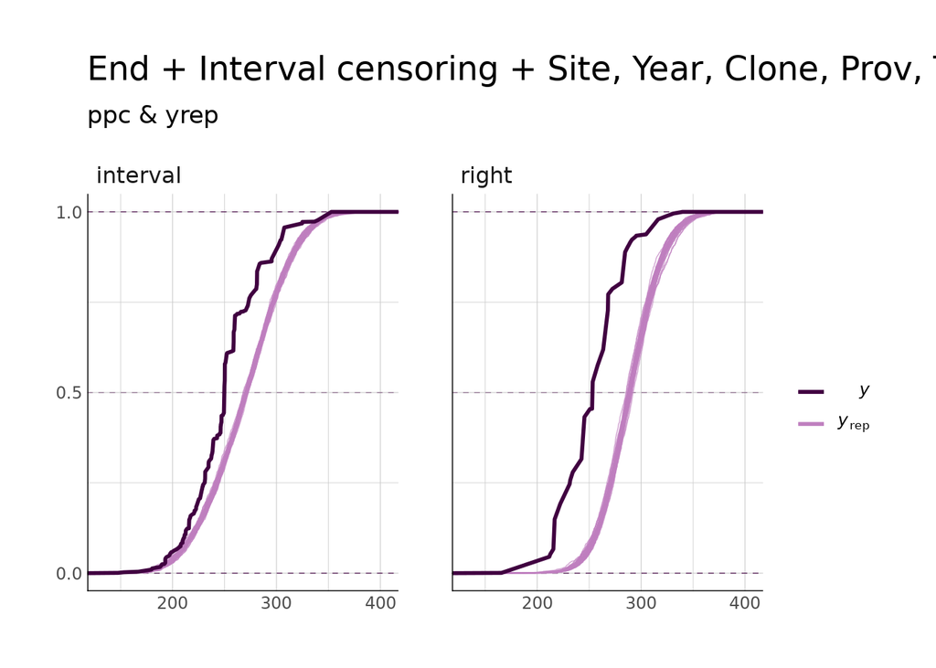

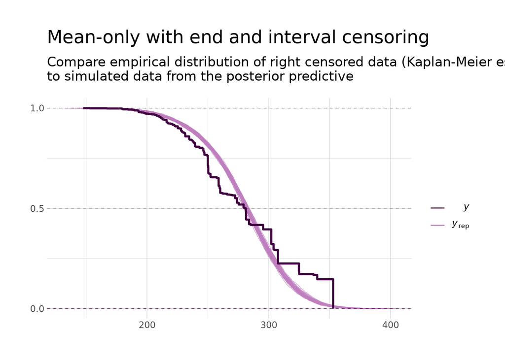

# Model comparison

While we might hope the KM estimate looked better, model performance is better for a model that incorporates heterogeneity from Site, Provenance, Year, and Clone along with end and interval censoring. Including tree makes the model “worse”, but not meaningfully, and lets us separate tree level from clone level variation.

```
##      elpd_diff se_diff
## ec       0.0       0.0
## ect     -0.7       1.1
## mocf -1086.7      39.2
```